# Nora Master Project Data Analysis Notebook

Nora Luo

# Table of Contents

1. Notation
2. Load and split the data
3. Screening Questions
4. Actual Survey Analysis
5. Statistical Testing

# README

- run the Load and split the data chunk first
- results was filtered based on Q3.9 - whether respondents understand the concept of inflation
- ! : We can reject the null hypothesis.

# Load and split the data

```r
library(readr)
library(dplyr)
library(ggplot2)
library(tidyr)
library(FSA)
library(car)



exported_data <- read_csv("rawdata_value.csv")
exported_data <- subset(exported_data, select = -c(StartDate,EndDate,Status,IPAddress,Progress,Finished,RecordedDate, RecipientLastName,RecipientFirstName,                                  RecipientEmail,ExternalReference,LocationLatitude,LocationLongitude,DistributionChannel,UserLanguage))
rawdata_value <- subset(exported_data, select =-c(ResponseId,Q1.1,Q2.1))
rawdata_value <- rawdata_value[3:nrow(rawdata_value), ]

# label the group
rawdata_value <- rawdata_value %>%
  mutate(group = case_when(
    !is.na(Q4.2)  ~ '0-controlled',
    !is.na(Q6.2)  ~ '1-errorbar',
    !is.na(Q8.2)  ~ '2-shadedbar',
    !is.na(Q10.2) ~ '3-fanchartslice',
    !is.na(Q12.2) ~ '4-bellcurve'
  ))
# create a copy of the data for Q3.9 analysis
rawdata_q3_9 <- rawdata_value
# filter participants who do not understand the concept of inflation
rawdata_value <- rawdata_value[rawdata_value$Q3.9 == "4", ]

# rawdata_value <- rawdata_value %>%
#   mutate(group = case_when(
#     !is.na(Q4.2)  ~ 0,
#     !is.na(Q6.2)  ~ 1,
#     !is.na(Q8.2)  ~ 2,
#     !is.na(Q10.2) ~ 3,
#     !is.na(Q12.2) ~ 4
#   ))

# meta-data
total_respondents <- nrow(rawdata_value)

group_total <- rawdata_value %>%
  group_by(group) %>%
  summarise(n_respondents = n())

# filter treatment groups
controlled_group <- rawdata_value[!is.na(rawdata_value$Q4.2), ]
error_bar <-rawdata_value[!is.na(rawdata_value$Q6.2), ]
shaded_bar <-rawdata_value[!is.na(rawdata_value$Q8.2), ]
fanchart_slice <-rawdata_value[!is.na(rawdata_value$Q10.2), ]
bell_curve <-rawdata_value[!is.na(rawdata_value$Q12.2), ]

# adding labels to the groups
# controlled_group$group <- 1
# error_bar$group <- 2
# shaded_bar$group <- 3
# fanchart_slice$group <- 4
# bell_curve$group <- 5


# remove unnecessary columns
controlled_group = controlled_group[,grepl("^(Q3|Q4|Q5)",names(controlled_group))|names(controlled_group) %in% c("Duration (in seconds)", "group")]
error_bar = error_bar[,grepl("^(Q3|Q6|Q7)",names(error_bar))| names(error_bar) %in% c("Duration (in seconds)", "group")]
shaded_bar = shaded_bar[,grepl("^(Q3|Q8|Q9)",names(shaded_bar))| names(shaded_bar)%in% c("Duration (in seconds)", "group")]
fanchart_slice = fanchart_slice[,grepl("^(Q3|Q10|Q11)",names(fanchart_slice))| names(fanchart_slice) %in% c("Duration (in seconds)", "group")]
bell_curve = bell_curve[,grepl("^(Q3|Q12|Q13)",names(bell_curve))| names(bell_curve) %in% c("Duration (in seconds)", "group")]
# controlled_group = controlled_group[,!sapply(controlled_group, function(x) mean(is.na(x)))>0.9]

group_list <- list(
  controlled = controlled_group,
  errorbar = error_bar,
  shadedbar = shaded_bar,
  fanchartslice = fanchart_slice,
  bellcurve = bell_curve
)
```

# Screening Questions

## ! Time Duration

```r
time_duration_table <- rawdata_value[,c("Duration (in seconds)", "group")]
time_duration_table$`Duration (in mins)` <- as.numeric(time_duration_table$`Duration (in seconds)`)/60

# report quantile information
summary(time_duration_table$`Duration (in mins)`)
```

```
   Min. 1st Qu.  Median    Mean 3rd Qu.    Max.
  4.117  13.967  19.883  22.524  27.133  85.233
```

```r
# test for normality --> It's definitely not normal distribution
# shapiro.test(time_duration_table$`Duration (in mins)`)

# run the kruskal-wallis test
kruskal_test <- kruskal.test(`Duration (in mins)` ~ group, data = time_duration_table)
print(kruskal_test)
```

```
    Kruskal-Wallis rank sum test

data:  Duration (in mins) by group
Kruskal-Wallis chi-squared = 22.226, df = 4, p-value = 0.0001807
```

```r
# run post-hoc test
dunn_test <- dunnTest(`Duration (in mins)` ~ group, data = time_duration_table, method = "bonferroni")
print(dunn_test)
```

```
Dunn (1964) Kruskal-Wallis multiple comparison
  p-values adjusted with the Bonferroni method.
```

| Comparison | Z | P.unadj | P.adj |
| --- | --- | --- | --- |
| 0-controlled - 1-errorbar | -3.3371870 | 8.463097e-04 | 0.0084630971 |
| 0-controlled - 2-shadedbar | -4.2383637 | 2.251548e-05 | 0.0002251548 |
| 1-errorbar - 2-shadedbar | -0.8994583 | 3.684086e-01 | 1.0000000000 |
| 0-controlled - 3-fanchartslice | -3.8348082 | 1.256623e-04 | 0.0012566233 |
| 1-errorbar - 3-fanchartslice | -0.4770229 | 6.333458e-01 | 1.0000000000 |
| 2-shadedbar - 3-fanchartslice | 0.4279299 | 6.687022e-01 | 1.0000000000 |
| 0-controlled - 4-bellcurve | -2.6716347 | 7.548278e-03 | 0.0754827779 |
| 1-errorbar - 4-bellcurve | 0.6457377 | 5.184493e-01 | 1.0000000000 |
| 2-shadedbar - 4-bellcurve | 1.5400043 | 1.235593e-01 | 1.0000000000 |
| 3-fanchartslice - 4-bellcurve | 1.1238278 | 2.610861e-01 | 1.0000000000 |

Time duration summary table

```r
time_duration_summary <- time_duration_table %>%
  group_by(group) %>%
  summarise(mean_duration = mean(`Duration (in mins)`, na.rm = TRUE),
            sd_duration = sd(`Duration (in mins)`, na.rm = TRUE),
            .groups = 'drop')
```

Plot the distribution of different groups

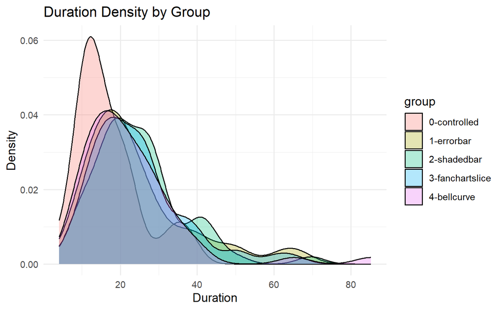

Plot time duration bar chart. It’s not valid as the data is not normal distribution.

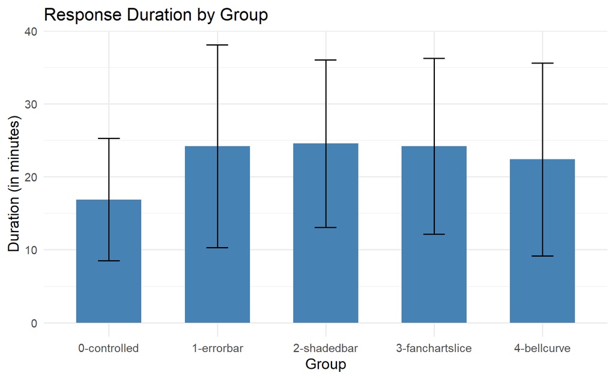

```r
ggplot(time_duration_summary, aes(x = group, y = mean_duration)) +
  geom_bar(stat = "identity", fill = "steelblue", width = 0.6) +
  geom_errorbar(aes(ymin = mean_duration - sd_duration, ymax = mean_duration + sd_duration), width = 0.2) +
  labs(title = "Response Duration by Group",
       y = "Duration (in minutes)",
       x = "Group") +
  theme_minimal()
```

## Q3.2 Age

What is your age?  
Variable: continuous  
Method: kruskal-wallis test  
**Result: Fail to reject the null hypothesis**

```r
kruskal_test <- kruskal.test(`Q3.2` ~ group, data = age_table)
print(kruskal_test)
```

```
    Kruskal-Wallis rank sum test

data:  Q3.2 by group
Kruskal-Wallis chi-squared = 2.5182, df = 4, p-value = 0.6414
```

## Q3.3 Gender

Which of the following best describes your gender identity?  
Variable: categorical  
Method: contingency Table + chi-squared test  
**Result: Fail to reject the null hypothesis**

```r
q3_3_table <- rawdata_value[, c("Q3.3", "group")]
# q3_3_table$Q3.3 <- recode(q3_3_table$Q3.3,
#                                     "1" = "Male",
#                                     "2" = "Female",
#                                     .default = "Other")
q3_3_contingency <- table(q3_3_table$Q3.3, q3_3_table$group)
print(q3_3_contingency)
```

[output not shown]

```r
# Chi-squared test
chisq.test(q3_3_contingency)
```

```
    Pearson's Chi-squared test

data:  q3_3_contingency
X-squared = 8.6715, df = 12, p-value = 0.7307
```

Calculate the gender percentage

```r
# percentage of male
male_per <- q3_3_contingency[1,]
gender_group_total <- colSums(q3_3_contingency)
male_prop <- male_per/gender_group_total
```

## Q3.4 Highest Education

What is your highest level of education achieved?  
Variable: categorical with written insights from choice 9 Method: contingency Table + chi-squared test  
**Result: Fail to reject the null hypothesis**

```r
q3_4_table <- rawdata_value[rawdata_value$`Q3.4` != "9", c("Q3.4", "group")]

q3_4_contingency <- table(q3_4_table$Q3.4, q3_4_table$group)
# Chi-squared test
chisq.test(q3_4_contingency)
```

```
    Pearson's Chi-squared test

data:  q3_4_contingency
X-squared = 23.658, df = 28, p-value = 0.6995
```

Highest Education Level proportion bar plot across different groups

```r
q3_4_prop  <- as.data.frame(q3_4_contingency)
# rename columns
names(q3_4_prop) <- c("Q3.4", "Group", "Count")

# calculate proportions within each group
q3_4_prop <- q3_4_prop %>%
  group_by(Group) %>%
  mutate(Proportion = Count / sum(Count))

ggplot(q3_4_prop, aes(x = as.factor(`Q3.4`), y = Proportion, fill = Group)) +
  geom_bar(stat = "identity", position = "dodge") +
  # facet_wrap(~ Group) +
  labs(
    title = "Q3.4 Highest Education Level Propotion Plot across Groups",
    x = "Response",
    y = "Proportion"
  ) +
  # scale_x_discrete(labels = c(
  #   "1" = "No formal education",
  #   "2" = "Primary/Elementary",
  #   "3" = "Secondary School (GCSE)",
  #   "4" = "High School (A Level)",
  #   "5" = "Technical or Vocational",
  #   "6" = "Bachelors or equivalent degree level qualification",
  #   "7" = "Masters or equivalent higher degree level qualification",
  #   "8" = "PhD or equivalent doctoral level qualification"))+
   scale_fill_brewer(palette = "Set2")+
  scale_y_continuous(labels = scales::percent_format(accuracy = 1)) +
  theme_minimal() +
  theme(axis.text.x = element_text(angle = 45, hjust = 1))
```

[output not shown]

Plot pie chart including all participants

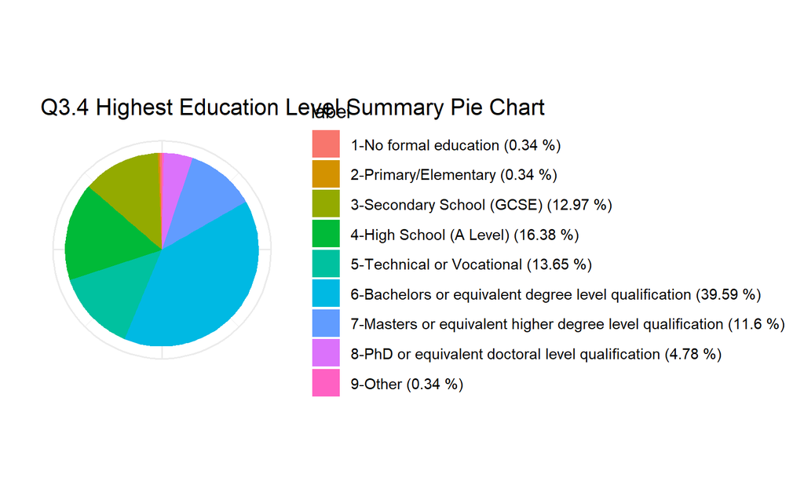

```r
q3_4_table <- rawdata_value[, c("Q3.4", "group")]

# Q3.4 summary table
q3_4_summary <- q3_4_table %>%
  group_by(`Q3.4`) %>%
  summarise(count = n()) %>%
  mutate(proportion = count / sum(count),
         label =
            case_when(
              Q3.4 == "1" ~ "1-No formal education",
              Q3.4 == "2" ~ "2-Primary/Elementary",
              Q3.4 == "3" ~ "3-Secondary School (GCSE)",
              Q3.4 == "4" ~ "4-High School (A Level)",
              Q3.4 == "5" ~ "5-Technical or Vocational",
              Q3.4 == "6" ~ "6-Bachelors or equivalent degree level qualification",
              Q3.4 == "7" ~ "7-Masters or equivalent higher degree level qualification",
              Q3.4 == "8" ~ "8-PhD or equivalent doctoral level qualification",
              Q3.4 == "9" ~ "9-Other"
            ),
         label = paste0(label, " (", round(proportion * 100, 2), " %)")
         )

ggplot(q3_4_summary, aes(x = "",y = proportion, fill = label)) +
  geom_col(width = 1) +
  coord_polar(theta = "y") +
  labs(title = "Q3.4 Highest Education Level Summary Pie Chart",
       x = "",
       y = "") +
  theme_minimal() +
  theme(axis.text.x = element_blank())
```

## Q3.5 Employee Status

What is your current profession or employment status?  
Variable: categorical  
Method: contingency Table + chi-squared test  
**Result: Fail to reject the null hypothesis**

```r
q3_5_table <- rawdata_value[rawdata_value$`Q3.5` != "6", c("Q3.5", "group")]
q3_5_contingency <- table(q3_5_table$Q3.5, q3_5_table$group)
# print(q3_5_contingency)

# Chi-squared test
chisq.test(q3_5_contingency)
```

```
    Pearson's Chi-squared test

data:  q3_5_contingency
X-squared = 23.174, df = 16, p-value = 0.1092
```

Employee status proportion bar plot across different groups

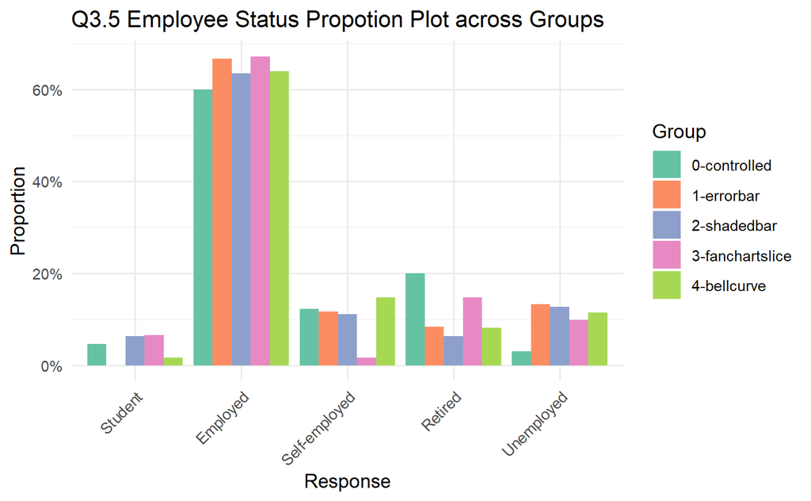

```r
q3_5_prop  <- as.data.frame(q3_5_contingency)
# rename columns
names(q3_5_prop) <- c("Q3.5", "Group", "Count")


# calculate proportions within each group
q3_5_prop <- q3_5_prop %>%
  group_by(Group) %>%
  mutate(Proportion = Count / sum(Count))

ggplot(q3_5_prop, aes(x = as.factor(`Q3.5`), y = Proportion, fill = Group)) +
  geom_bar(stat = "identity", position = "dodge") +
  # facet_wrap(~ Group) +
  labs(
    title = "Q3.5 Employee Status Propotion Plot across Groups",
    x = "Response",
    y = "Proportion"
  ) +
  scale_x_discrete(labels = c(
    "1" = "Student",
    "2" = "Employed",
    "3" = "Self-employed",
    "4" = "Retired",
    "5" = "Unemployed"
  )) +
   scale_fill_brewer(palette = "Set2")+
  scale_y_continuous(labels = scales::percent_format(accuracy = 1)) +
  theme_minimal() +
  theme(axis.text.x = element_text(angle = 45, hjust = 1))
```

Plot pie chart including all participants

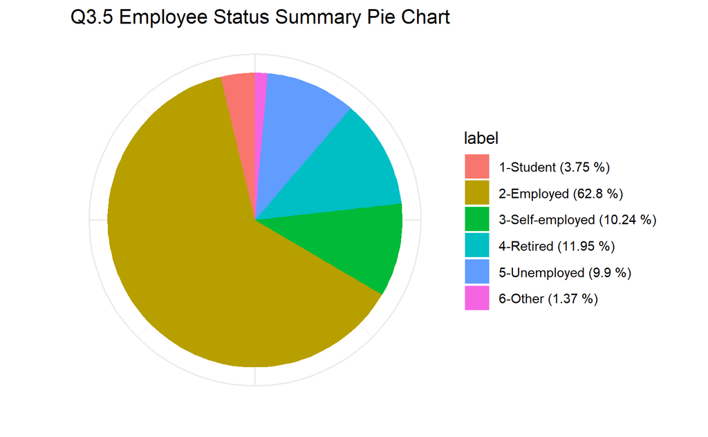

```r
q3_5_table <- rawdata_value[, c("Q3.5", "group")]
q3_5_summary <- q3_5_table %>%
  group_by(`Q3.5`) %>%
  summarise(count = n()) %>%
  mutate(proportion = count / sum(count),
         label =
            case_when(
              Q3.5 == "1" ~ "1-Student",
              Q3.5 == "2" ~ "2-Employed",
              Q3.5 == "3" ~ "3-Self-employed",
              Q3.5 == "4" ~ "4-Retired",
              Q3.5 == "5" ~ "5-Unemployed",
              Q3.5 == "6" ~ "6-Other"
            ),
         label = paste0(label, " (", round(proportion * 100, 2), " %)")
         )
ggplot(q3_5_summary, aes(x = "",y = proportion, fill = label)) +
  geom_col(width = 1) +
  coord_polar(theta = "y") +
  labs(title = "Q3.5 Employee Status Summary Pie Chart",
       x = "",
       y = "") +
  theme_minimal() +
  theme(axis.text.x = element_blank())
```

## Q3.6 Economics Education

In which, if any, have you ever studied economics? (Select all that apply)  
Variable: categorical  
Method: convert to list and count + chi-squared test  
**Result: Fail to reject the null hypothesis**

Plot percentage bar chart including all participants

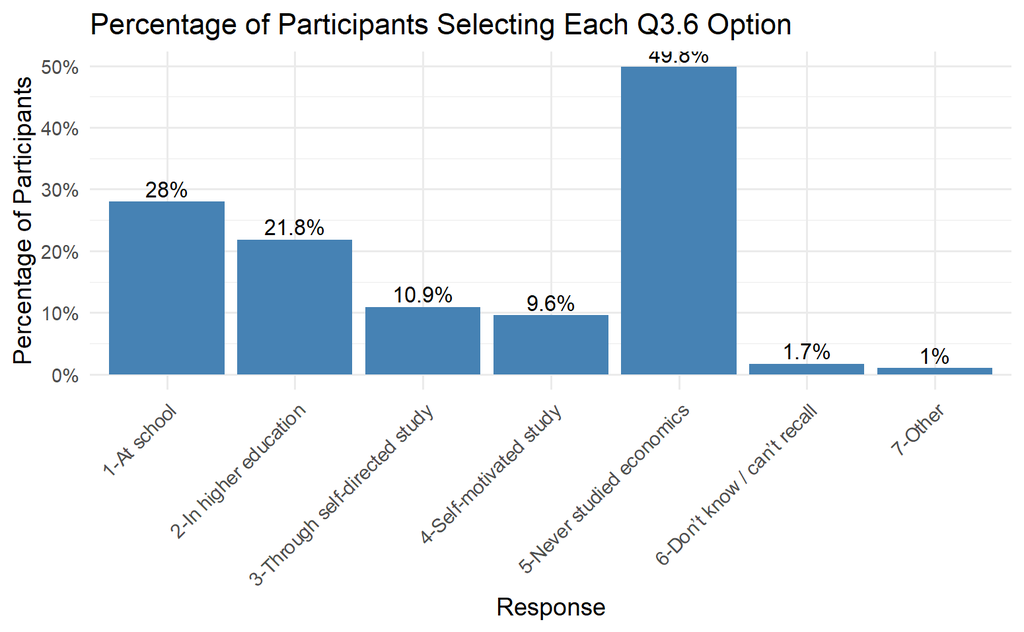

```r
q3_6_table <- rawdata_value[, c("Q3.6", "group")]
q3_6_table$Q3.6 <- lapply(q3_6_table$Q3.6, function(x) as.list(as.numeric(strsplit(x, ",")[[1]])))

# count the number of occurrences of each value
q3_6_summary <- q3_6_table %>%
  unnest(Q3.6) %>%
  group_by(`Q3.6`) %>%
  summarise(count = n()) %>%
  mutate(proportion = count / total_respondents,
         label =
            case_when(
              Q3.6 == "1" ~ "1-At school",
              Q3.6 == "2" ~ "2-In higher education",
              Q3.6 == "3" ~ "3-Through self-directed study",
              Q3.6 == "4" ~ "4-Self-motivated study",
              Q3.6 == "5" ~ "5-Never studied economics",
              Q3.6 == "6" ~ "6-Don’t know / can’t recall",
              Q3.6 == "7" ~ "7-Other"
            ))

# q3_6_summary$Q3.6 <- as.numeric(q3_6_summary$Q3.6)
ggplot(q3_6_summary, aes(x = factor(label), y = proportion)) +
  geom_col(fill = "steelblue") +
  geom_text(aes(label = paste0(round(proportion * 100, 1), "%")),
            vjust = -0.3, size = 3.5) +
  scale_y_continuous(labels = scales::percent_format(accuracy = 1)) +
  labs(
    title = "Percentage of Participants Selecting Each Q3.6 Option",
    x = "Response",
    y = "Percentage of Participants"
  ) +
  theme_minimal() +
  theme(axis.text.x = element_text(angle = 45, hjust = 1))
```

```r
q3_6_table <- rawdata_value[, c("Q3.6", "group")]
q3_6_table$Q3.6 <- lapply(q3_6_table$Q3.6, function(x) as.list(as.numeric(strsplit(x, ",")[[1]])))
# count the number of occurrences of each value
q3_6_prop <- q3_6_table %>%
  unnest(Q3.6) %>%
  group_by(group, Q3.6) %>%
  summarise(count = n(), .groups = 'drop')
q3_6_prop$Q3.6 <- as.numeric(q3_6_prop$Q3.6)

# create a contingency table
q3_6_contingency <- xtabs(count ~ Q3.6 + group, data = q3_6_prop)
print(q3_6_contingency)
```

```
    group
Q3.6 0-controlled 1-errorbar 2-shadedbar 3-fanchartslice 4-bellcurve
   1           12         20          13              16          21
   2            8         10          17              18          11
   3            4          8           8               7           5
   4            4          6           5               8           5
   5           36         28          28              28          26
   6            2          0           1               1           1
   7            0          2           0               0           1
```

```r
# Chi-squared test
chisq.test(q3_6_contingency)
```

```
    Pearson's Chi-squared test

data:  q3_6_contingency
X-squared = 22.428, df = 24, p-value = 0.5537
```

```r
# q3_6_test <-q3_6_prop %>%
#   group_by(`Q3.6`) %>%
#   summarise(total_count = sum(count), .groups = "drop")
```

Economics Education proportion bar plot across different groups

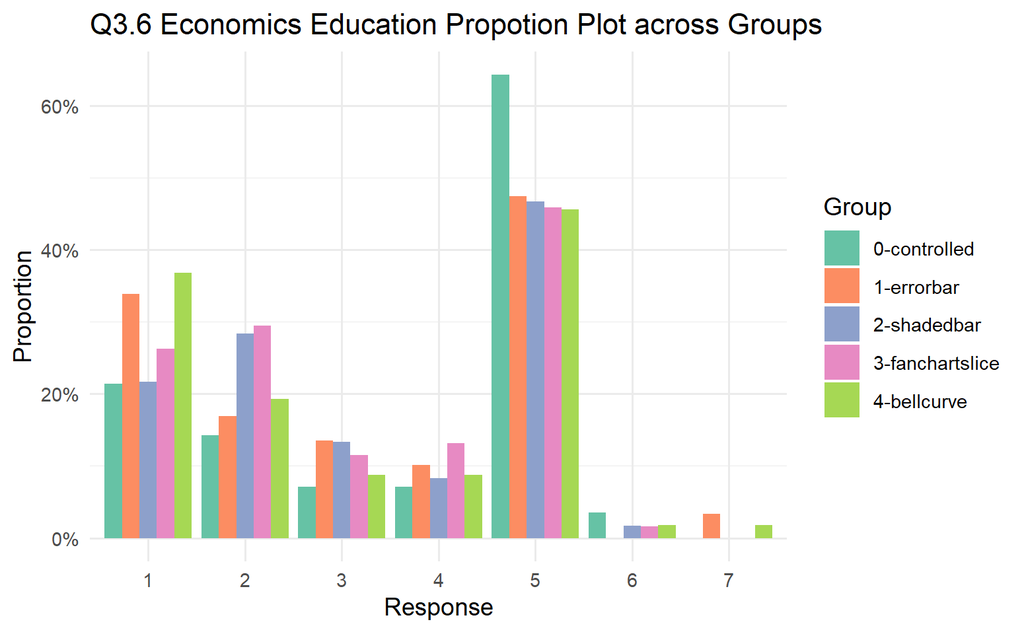

```r
# convert contingency table to data frame # count 0 as well
q3_6_prop <- as.data.frame(q3_6_contingency)
# calculate proportions within each group
q3_6_prop <- q3_6_prop %>%
  left_join(group_total, by = "group") %>%
  mutate(Proportion = Freq / n_respondents)

ggplot(q3_6_prop, aes(x = factor(Q3.6), y = Proportion, fill = factor(group))) +
  geom_col(position = "dodge") +
  labs(
    title = "Q3.6 Economics Education Propotion Plot across Groups",
    x = "Response",
    y = "Proportion",
    fill = "Group"
  ) +
  scale_fill_brewer(palette = "Set2")+
  scale_y_continuous(labels = scales::percent_format(accuracy = 1)) +
  theme_minimal()
```

## Q3.7 Financial Activities

Which of the following financial activities do you actively participate in? (Select all that apply) - Selected Choice Fixed Income (e.g., government bonds, corporate bonds)  
Variable: categorical  
Method: convert to list and count + chi-squared test  
**Result: Fail to reject the null hypothesis**

```r
q3_7_table <- rawdata_value[, c("Q3.7", "group")]
q3_7_table$Q3.7 <- lapply(q3_7_table$Q3.7, function(x) as.list(as.numeric(strsplit(x, ",")[[1]])))
# count the number of occurrences of each value in each group
q3_7_prop <- q3_7_table %>%
  unnest(Q3.7) %>%
  group_by(group,`Q3.7`) %>%
  summarise(count = n(), .groups = 'drop')
q3_7_prop$Q3.7 <- as.numeric(q3_7_prop$Q3.7)

# create a contingency table
q3_7_contingency <- xtabs(count ~ `Q3.7` + group, data = q3_7_prop)
print(q3_7_contingency)
```

```
    group
Q3.7 0-controlled 1-errorbar 2-shadedbar 3-fanchartslice 4-bellcurve
  11           49         53          51              59          48
  12           25         32          29              33          26
  13            9         16           8               7          10
  14           29         35          31              25          29
  15            3         13           5               9           4
  16            1          8           2               6           6
  17            9         14          13              12           9
  18            4          4           5               2           7
  19            1          2           0               0           0
```

```r
# Chi-squared test
chisq.test(q3_7_contingency)
```

```
    Pearson's Chi-squared test

data:  q3_7_contingency
X-squared = 28.26, df = 32, p-value = 0.6564
```

Plot financial activities proportion bar plot across different groups

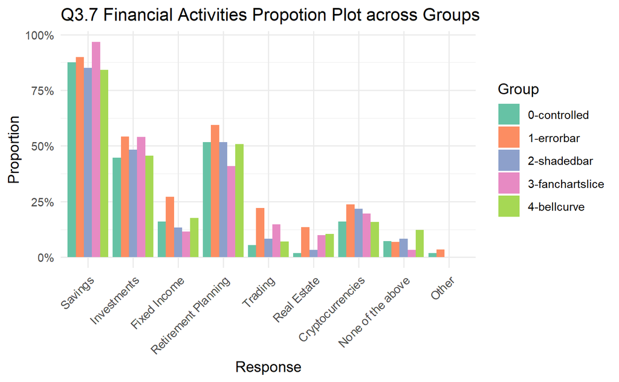

```r
# convert contingency table to data frame
q3_7_prop <- as.data.frame(q3_7_contingency) %>%
  left_join(group_total, by = "group") %>%
  mutate(Proportion = Freq / n_respondents)


ggplot(q3_7_prop, aes(x = factor(`Q3.7`), y = Proportion, fill = factor(group))) +
  geom_col(position = "dodge") +
  labs(
    title = "Q3.7 Financial Activities Propotion Plot across Groups",
    x = "Response",
    y = "Proportion",
    fill = "Group"
  ) +
    scale_x_discrete(labels = c(
    "11" = "Savings",
    "12" = "Investments",
    "13" = "Fixed Income",
    "14" = "Retirement Planning",
    "15" = "Trading",
    "16" = "Real Estate",
    "17" = "Cryptocurrencies",
    "18" = "None of the above",
    "19" = "Other"
      )) +
  scale_fill_brewer(palette = "Set2")+
  scale_y_continuous(labels = scales::percent_format(accuracy = 1)) +
  theme_minimal() +
  theme(axis.text.x = element_text(angle = 45, hjust = 1))
```

## Q3.8 Awareness of Economics

How frequently, if at all, do you read/watch/listen to news stories related to economics or the economy?  
Variable: categorical  
Method: contingency table + chi-squared test  
**Result: Fail to reject the null hypothesis**

```r
chisq.test(q3_8_contingency[-nrow(q3_8_contingency), ])
```

```
    Pearson's Chi-squared test

data:  q3_8_contingency[-nrow(q3_8_contingency), ]
X-squared = 30.527, df = 20, p-value = 0.06175
```

Awareness of Economics proportion bar plot across different groups

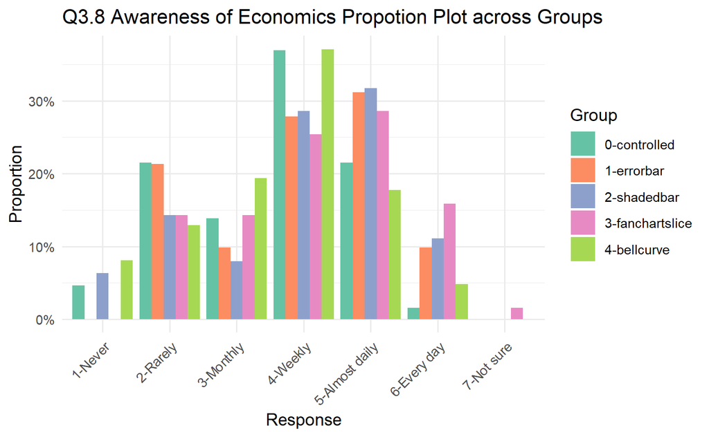

```r
q3_8_prop  <- as.data.frame(q3_8_contingency)
# rename columns
names(q3_8_prop) <- c("Q3.8", "Group", "Count")

# add a labelled column
q3_8_prop <- q3_8_prop %>%
  mutate(Q3.8_label = case_when(
    Q3.8 == "1" ~ "1-Never",
    Q3.8 == "2" ~ "2-Rarely",
    Q3.8 == "3" ~ "3-Monthly",
    Q3.8 == "4" ~ "4-Weekly",
    Q3.8 == "5" ~ "5-Almost daily",
    Q3.8 == "6" ~ "6-Every day",
    Q3.8 == "7" ~ "7-Not sure"
  ))

# calculate proportions within each group
q3_8_prop <- q3_8_prop %>%
  group_by(Group) %>%
  mutate(Proportion = Count / sum(Count))

ggplot(q3_8_prop, aes(x = as.factor(`Q3.8_label`), y = Proportion, fill = Group)) +
  geom_col(position = "dodge") +
  # facet_wrap(~ Group) +
  labs(
    title = "Q3.8 Awareness of Economics Propotion Plot across Groups",
    x = "Response",
    y = "Proportion"
  ) +
   scale_fill_brewer(palette = "Set2")+
  scale_y_continuous(labels = scales::percent_format(accuracy = 1)) +
  theme_minimal()+
  theme(axis.text.x = element_text(angle = 45, hjust = 1))
```

## Q3.9 Inflation Knowledge

To the best of your knowledge, which option most accurately describes what inflation is?  
Definitive correct answer  
Variable: categorical  
Method: descriptive analysis  
**Respondents were filtered based on whether if they can understand what inflation is.**

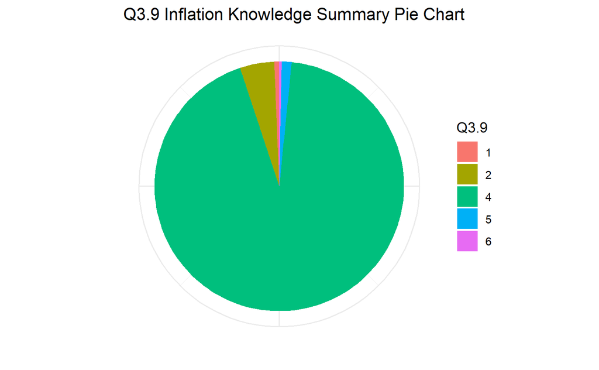

```r
q3_9_table <- rawdata_q3_9[, c("Q3.9", "group")]
q3_9_summary <- q3_9_table %>%
  group_by(`Q3.9`) %>%
  summarise(count = n()) %>%
  mutate(proportion = count / sum(count))

  ggplot(q3_9_summary, aes(x = "",y = proportion, fill = `Q3.9`)) +
  geom_col(width = 1) +
  coord_polar(theta = "y") +
  labs(title = "Q3.9 Inflation Knowledge Summary Pie Chart",
       x = "",
       y = "") +
  theme_minimal() +
  theme(axis.text.x = element_blank())
```

## Q3.11 Trust of Official Data

How much do you trust official inflation forecasts (For instance, the forecasts released by the Bank of England)?  
*ascending value + exclude 6- Unsure / no opinion*  
Variable: treat as continuous  
Method: Kruskal-Wallis test  
**Result: Fail to reject the null hypothesis**

```r
q3_11_table <- rawdata_value[rawdata_value$`Q3.11` != "6", c("Q3.11", "group")]
q3_11_table$Q3.11 <- as.numeric(q3_11_table$`Q3.11`)
# check normality --> Not normally distributed
# shapiro.test(q3_11_table$Q3.11)
# bartlett.test(`Q3.11` ~ group, data = q3_11_table)


# run kruskal test
kruskal_test <- kruskal.test(Q3.11 ~ group, data = q3_11_table)
print(kruskal_test)

q3_11_summary <- q3_11_table %>%
  group_by(group) %>%
  summarise(q3_11_mean = mean(as.numeric(Q3.11), na.rm = TRUE),
            q3_11_sd = sd(as.numeric(Q3.11), na.rm = TRUE),
            .groups = 'drop')

# report quantile information
summary(q3_11_table$Q3.11)
```

[output not shown]

Plot the distribution of different groups

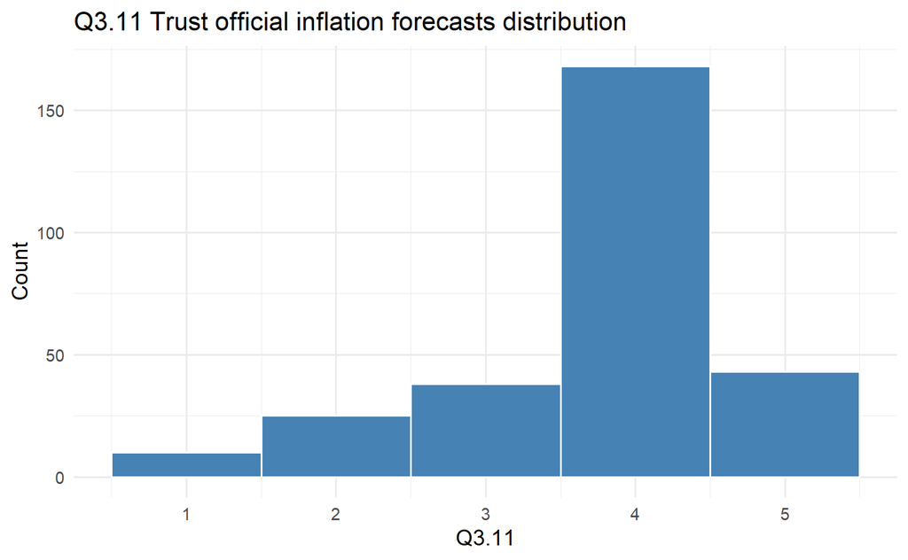

```r
# histogram including all participants
ggplot(q3_11_table, aes(x = Q3.11)) +
  geom_histogram(binwidth = 1, fill = "steelblue", color = "white") +
  # facet_wrap(~ group) +
  labs(title = "Q3.11 Trust official inflation forecasts distribution",
       x = "Q3.11",
       y = "Count") +
  scale_x_continuous(breaks = seq(0, max(q3_11_table$Q3.11, na.rm = TRUE), by = 1)) +
  theme_minimal()
```

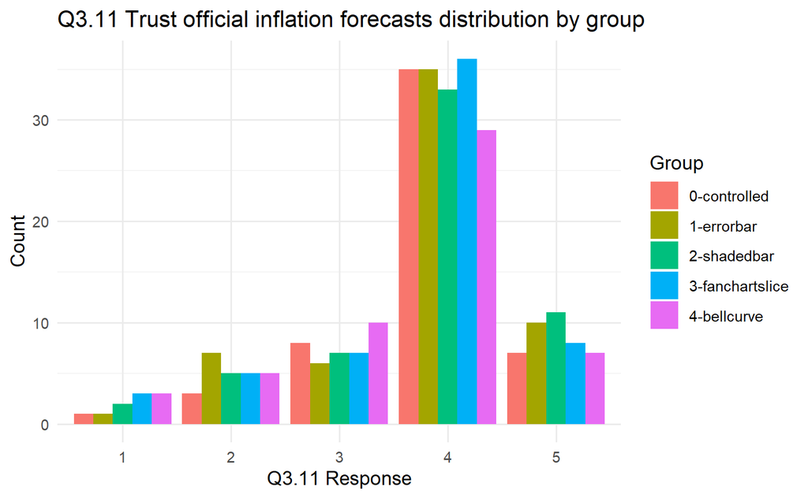

```r
# Grouped bar-style histogram
ggplot(q3_11_table, aes(x = factor(Q3.11), fill = factor(group))) +
  geom_bar(position = "dodge") +
  labs(
    title = "Q3.11 Trust official inflation forecasts distribution by group",
    x = "Q3.11 Response",
    y = "Count",
    fill = "Group"
  ) +
  theme_minimal()
```